# Pivoting datasets

# 1 Learning Objectives

# 2 Packages

# 3 What do wide and long mean?

- Understand by examples
- Example 1: blood pressure data from three patients on three days.

  WIDE format:

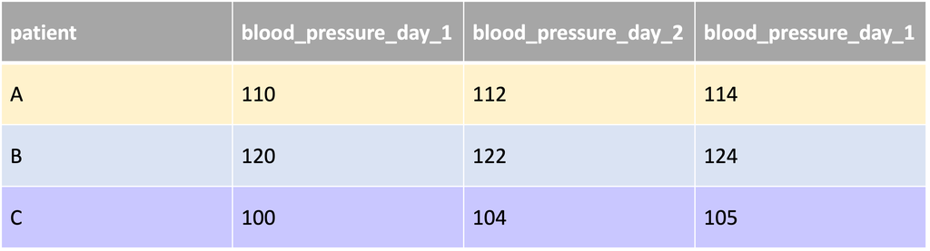

Fig: wide dataset for a timeseries of patients.

LONG format:

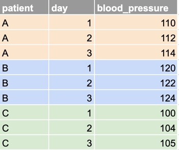

Fig: long dataset for a timeseries of patients.

- Example 2: observational units are countries

LONG format:

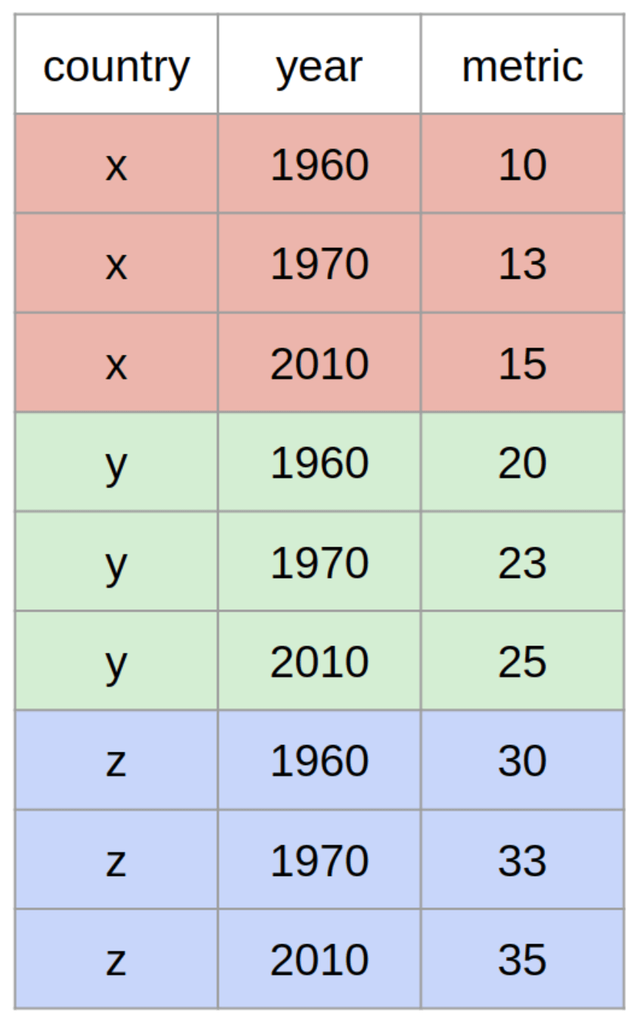

Fig: long dataset where the unique observation unit is a country.

WIDE format:

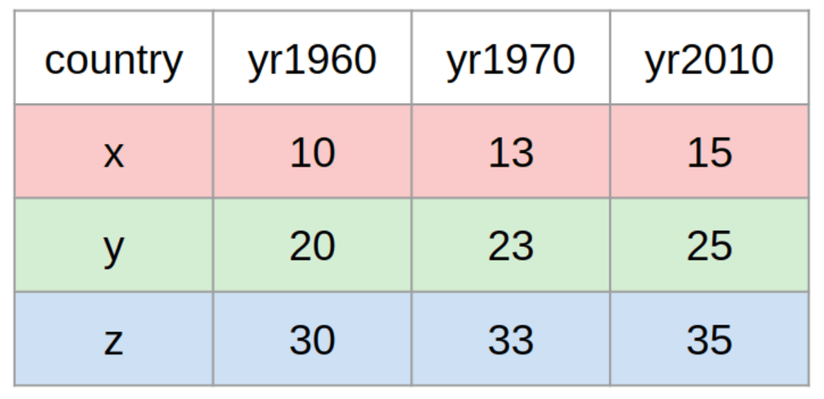

Fig: the equivalent wide dataset

- Examples above = time-series datasets
- Example 3: the number of patients in different units of three hospitals

WIDE format:

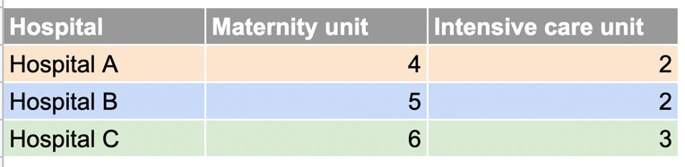

Fig: wide dataset, where each hospital is an observational unit

LONG format:

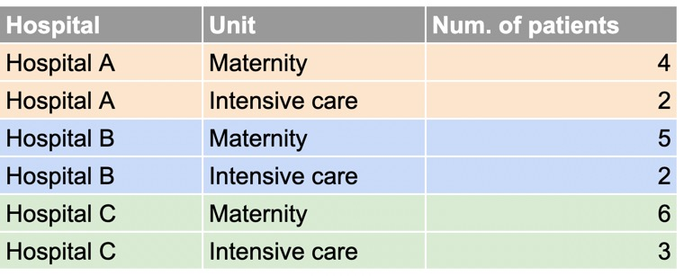

Fig: the equivalent long dataset

“observational units” = “statistical units” = primary entities described by the columns/variables

For example:

- a patient
- a country
- a hospital

Consider the mock dataset created below:

```r
temperatures <-
  data.frame(
    country = c("Sweden", "Denmark", "Norway"),
    avgtemp.1994 = 1:3,
    avgtemp.1995 = 3:5,
    avgtemp.1996 = 5:7)
temperatures
```

```
##   country avgtemp.1994 avgtemp.1995 avgtemp.1996
## 1  Sweden            1            3            5
## 2 Denmark            2            4            6
## 3  Norway            3            5            7
```

Is this data in a wide or long format?

```r
# Enter the string wide or the string long
# Assign your answer to the object Q_data_type
# Then run the CHECK function below
Q_data_type <- "wide"
```

# 4 When should you use wide vs long data?

- Depends on what you want to do!
- **wide format** = great for **displaying** data = easy to visually compare values
- **long format** = best for **data analysis** tasks = like grouping & plotting
- know how to **switch** from one format to the other
- switching from the wide to the long format = **pivoting**

# 5 Pivoting wide to long

- Data from [Gapminder](https://www.gapminder.org) on the **number of infant deaths** in specific countries over several years.

[Gapminder](https://www.gapminder.org) is a good source of **clean, rich health-relevant datasets.**

```r
infant_deaths_wide <- read_csv(here("data/gapminder_infant_deaths.csv"))
infant_deaths_wide
```

```
## # A tibble: 193 × 7
##    country              x2010 x2011 x2012 x2013 x2014 x2015
##    <chr>                <dbl> <dbl> <dbl> <dbl> <dbl> <dbl>
##  1 Afghanistan          74600 72000 69500 67100 64800 62700
##  2 Angola               79100 76400 73700 71200 69000 67200
##  3 Albania                420   384   354   331   313   301
##  4 United Arab Emirates   683   687   686   681   672   658
##  5 Argentina             9550  9230  8860  8480  8100  7720
##  6 Armenia                723   686   649   614   579   545
##  7 Antigua and Barbuda     12    11    11    10    10    10
##  8 Australia             1200  1160  1110  1080  1050  1030
##  9 Austria                280   273   266   260   255   253
## 10 Azerbaijan            5210  5070  4890  4670  4420  4140
## # ℹ 183 more rows
```

- observational unit = 1 country = 1 row
- repeated measurements spread out across multiple columns
- a wide format
- convert to a long format = `pivot_longer`.
- `cols` argument = which columns we want to pivot

```r
infant_deaths_wide %>%
  # we pivot longer the columns x2010 to x2015
  pivot_longer(cols = x2010:x2015)
```

```
## # A tibble: 1,158 × 3
##    country     name  value
##    <chr>       <chr> <dbl>
##  1 Afghanistan x2010 74600
##  2 Afghanistan x2011 72000
##  3 Afghanistan x2012 69500
##  4 Afghanistan x2013 67100
##  5 Afghanistan x2014 64800
##  6 Afghanistan x2015 62700
##  7 Angola      x2010 79100
##  8 Angola      x2011 76400
##  9 Angola      x2012 73700
## 10 Angola      x2013 71200
## # ℹ 1,148 more rows
```

```r
infant_deaths_wide %>%
  # we will set our names to "year" and the values to "death_counts"
  pivot_longer(cols = x2010:x2015,
               names_to = "years",
               values_to = "death count")
```

```
## # A tibble: 1,158 × 3
##    country     years `death count`
##    <chr>       <chr>         <dbl>
##  1 Afghanistan x2010         74600
##  2 Afghanistan x2011         72000
##  3 Afghanistan x2012         69500
##  4 Afghanistan x2013         67100
##  5 Afghanistan x2014         64800
##  6 Afghanistan x2015         62700
##  7 Angola      x2010         79100
##  8 Angola      x2011         76400
##  9 Angola      x2012         73700
## 10 Angola      x2013         71200
## # ℹ 1,148 more rows
```

Long format = more informative than the original wide format.

Why?

In the wide format, no idea what the 2D matrix of death counts represents

In the long format, the variable has a name.

- Side-note :
- Remove the `x` in front of each year.

```r
infant_deaths_wide %>%
  pivot_longer(cols = x2010:x2015,
               names_to = "years",
               values_to = "deaths_count") %>%
  # we use parse_number inside of mutate
  mutate( years = parse_number(years))
```

```
## # A tibble: 1,158 × 3
##    country     years deaths_count
##    <chr>       <dbl>        <dbl>
##  1 Afghanistan  2010        74600
##  2 Afghanistan  2011        72000
##  3 Afghanistan  2012        69500
##  4 Afghanistan  2013        67100
##  5 Afghanistan  2014        64800
##  6 Afghanistan  2015        62700
##  7 Angola       2010        79100
##  8 Angola       2011        76400
##  9 Angola       2012        73700
## 10 Angola       2013        71200
## # ℹ 1,148 more rows
```

Let’s store the data:

```r
infant_deaths_long <-
  infant_deaths_wide %>%
  pivot_longer(cols = x2010:x2015,
               names_to = "year",
               values_to = "deaths_count")
```

For this practice question, you will use the `euro_births_wide` dataset from [Eurostat](https://ec.europa.eu/eurostat/databrowser/view/tps00204/default/table). It shows the annual number of births in 50 European countries:

```r
euro_births_wide <-
  read_csv(here("data/euro_births_wide.csv"))
head(euro_births_wide)
```

```
## # A tibble: 6 × 8
##   country   x2015  x2016  x2017  x2018  x2019  x2020  x2021
##   <chr>     <dbl>  <dbl>  <dbl>  <dbl>  <dbl>  <dbl>  <dbl>
## 1 Belgium  122274 121896 119690 118319 117695 114350 118349
## 2 Bulgaria  65950  64984  63955  62197  61538  59086  58678
## 3 Czechia  110764 112663 114405 114036 112231 110200 111793
## 4 Denmark   58205  61614  61397  61476  61167  60937  63473
## 5 Germany  737575 792141 784901 787523 778090 773144 795492
## 6 Estonia   13907  14053  13784  14367  14099  13209  13272
```

The data is in a wide format. Convert it to a long format, with the following column names: “country”, “year” and “births_count”

```r
Q_euro_births_long <-
  euro_births_wide %>% # complete the code with your answer
  pivot_longer(cols = x2015:x2021,
               names_to = "year",
               values_to = "births_count")
Q_euro_births_long
```

# 6 Pivoting long to wide

- pivot the other way, from long to wide?
- Let’s first consider where you’re likely to run into long vs wide data:
  - Wide data tend to come from external sources
  - Long data is likely to be created by you while data wrangling.
- Let’s see an example of this now.
- Let’s see an example of this now.
- Datase of patient records from an Ebola outbreak in Sierra Leone in 2014
- We extract this data from the {outbreaks} package and perform some simplifying manipulations on it.

```r
ebola <-
  outbreaks::ebola_sierraleone_2014 |>
  as_tibble() |>
  mutate(year = lubridate::year(date_of_onset)) |>
  select(patient_id = id, district, year_of_onset = year)

ebola
```

```
## # A tibble: 11,903 × 3
##    patient_id district year_of_onset
##         <int> <fct>            <dbl>
##  1          1 Kailahun          2014
##  2          2 Kailahun          2014
##  3          3 Kailahun          2014
##  4          4 Kailahun          2014
##  5          5 Kailahun          2014
##  6          6 Kailahun          2014
##  7          7 Kailahun          2014
##  8          8 Kailahun          2014
##  9          9 Kailahun          2014
## 10         10 Kailahun          2014
## # ℹ 11,893 more rows
```

```r
ebola_sierraleone_2014
```

[output not shown]

Now, consider the following grouped summary of the `ebola` dataset, which counts the number of patients recorded in each district in each year:

```r
cases_per_district_per_year <-
  ebola %>%
  group_by(district) %>%
  count(year_of_onset) %>%
  ungroup()

cases_per_district_per_year
```

```
## # A tibble: 28 × 3
##    district year_of_onset     n
##    <fct>            <dbl> <int>
##  1 Bo                2014   397
##  2 Bo                2015   209
##  3 Bombali           2014  1070
##  4 Bombali           2015   120
##  5 Bonthe            2014     7
##  6 Bonthe            2015    77
##  7 Kailahun          2014   535
##  8 Kailahun          2015    35
##  9 Kambia            2014   127
## 10 Kambia            2015   294
## # ℹ 18 more rows
```

- This is a quintessentially “long” dataset! Each observational unit (each district) occupies multiple rows, with one row for each measurement (each year).
- Now, let’s see how to convert such long data into a wide format with `pivot_wider()`.
- Within this function, there are two important arguments:
  - `values_from` and `names_from`

```r
cases_per_district_per_year %>%
  pivot_wider(values_from = n,
              names_from = year_of_onset)
```

```
## # A tibble: 14 × 3
##    district      `2014` `2015`
##    <fct>          <int>  <int>
##  1 Bo               397    209
##  2 Bombali         1070    120
##  3 Bonthe             7     77
##  4 Kailahun         535     35
##  5 Kambia           127    294
##  6 Kenema           641    139
##  7 Koinadugu        142     15
##  8 Kono             328    223
##  9 Moyamba          258    191
## 10 Port Loko       1119    582
## 11 Pujehun           45     79
## 12 Tonkolili        541     42
## 13 Western Rural   1181    341
## 14 Western Urban   2068   1097
```

The `population` dataset from the `tidyr` package shows the populations of 219 countries over time.

Pivot this data into a wide format. Your answer should have 20 columns and 219 rows.

```r
Q_population_widen <-
  tidyr::population
```